# Project Documentation

2/22 8:30-9:30am: found leaflet and played around with it. I made a new shiny app to accommodate the new package.

```r
library(leaflet)
m <- leaflet("New York City") %>%
  addTiles() %>%  # Add default OpenStreetMap map tiles
  addMarkers(lng=-90.321, lat=40.31, popup="The birthplace of R")
m  # Print the map
```

[interactive chart not shown]

2/26 4-5pm: went to Mingi’s Mentor session and worked on mutating the data to show Uber pickups in different regions.

2/27 12:30 - 3pm: working on leaflet and made a basic choropleth map of NYC

```r
library(tigris)
library(dplyr)
library(leaflet)

# Downloading the shapefiles for states at the lowest resolution
nyc <- county_subdivisions("New York", c("Bronx", "Kings", "New York", "Queens", "Richmond"))
```

[output not shown]

[output cut: 103 more lines]

[output not shown]

```r
nyc %>%
  leaflet() %>%
  addTiles() %>%
  addPolygons(popup=~NAME)
```

[interactive chart not shown]

7-9pm: clean data to add a county column using latlong2country 9:30-11pm: working on joining spatial file with data frame source: https://stackoverflow.com/questions/13316185/r-convert-zipcode-or-lat-long-to-county

latlong2county takes the longitude and latitude data and returns a dataframe that contains all the counties based on lon and lat.

```r
library(sp)
library(dplyr)
library(stringr)
library(maps)
library(maptools)

# The single argument to this function, pointsDF, is a data.frame in which:
#   - column 1 contains the longitude in degrees (negative in the US)
#   - column 2 contains the latitude in degrees

# latlong2county returns the county based on lat and lon
latlong2county <- function(pointsDF) {
    # Prepare SpatialPolygons object with one SpatialPolygon
    # per county
    counties <- maps::map('county', fill=TRUE, col="transparent", plot=FALSE)
    IDs <- sapply(strsplit(counties$names, ":"), function(x) x[1])
    counties_sp <- map2SpatialPolygons(counties, IDs=IDs,
                     proj4string=CRS("+proj=longlat +datum=WGS84"))

    # Convert pointsDF to a SpatialPoints object
    pointsSP <- SpatialPoints(pointsDF,
                    proj4string=CRS("+proj=longlat +datum=WGS84"))

    # Use 'over' to get _indices_ of the Polygons object containing each point
    indices <- over(pointsSP, counties_sp)

    # Return the county names of the Polygons object containing each point
    countyNames <- sapply(counties_sp@polygons, function(x) x@ID)
    result <- c(countyNames[indices])
    word(result, 2, sep = fixed(","))
}

# Test the function using points in Wisconsin and Oregon.
testPoints <- data.frame(x = c(-90, -120), y = c(44, 44))

latlong2county(as.data.frame(head(select(uber, c("Lon", "Lat")))))
```

Ran into this problem where tidyverse also has a function map, so we need to use maps::map

The code below renders a choropleth map sources: https://learn.r-journalism.com/en/mapping/census_maps/census-maps/ https://rstudio.github.io/leaflet/shiny.html

```r
library(tidyverse)
library(sp)
library(dplyr)
library(tigris)
library(leaflet)
library(stringr)
library(maps)
library(maptools)
uber <- read_csv("uber_county.csv")
nyc_counties <- filter(counties("New York"), NAME %in% c("Bronx", "Kings", "New York", "Queens", "Richmond"))
# nyc converts all county names to lowercase
nyc <- mutate(nyc_counties, name = tolower(all_counties$NAME))
```

[output not shown]

3/5 4-5pm number of pickups based on date https://www.r-graph-gallery.com/279-plotting-time-series-with-ggplot2.html

```r
df_uber_date <- uber %>%
    group_by(date) %>%
    summarize(total=n())
glimpse(df_uber_date)
```

```
Rows: 30
Columns: 2
$ date  <date> 2014-06-01, 2014-06-02, 2014-06-03, 2014-06-04, 2014-06-0…
$ total <int> 15967, 17503, 22674, 22831, 28371, 24683, 20889, 15749, 23…
```

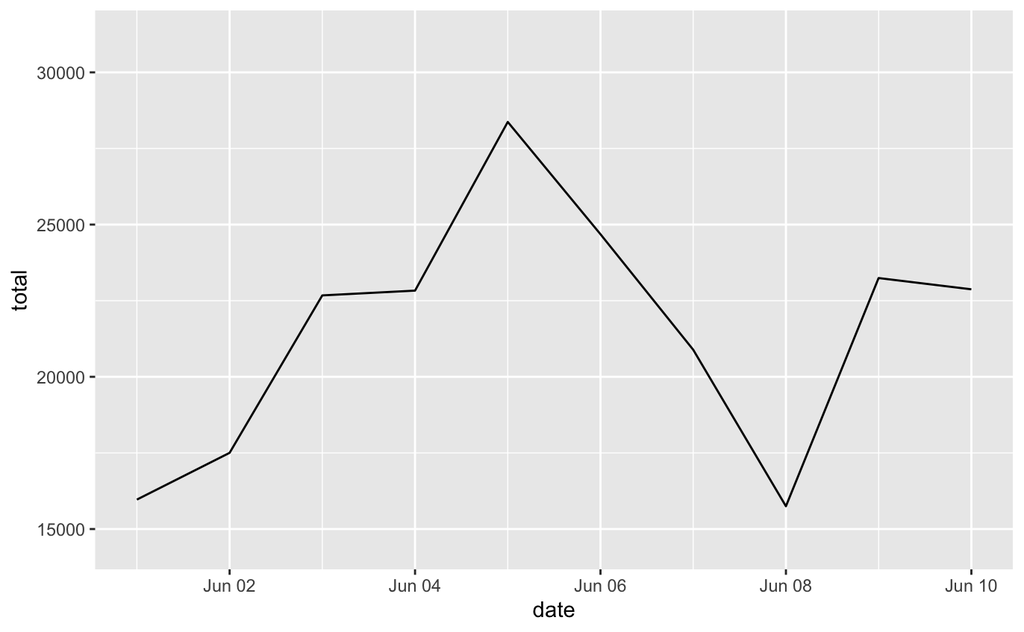

```r
p <- ggplot(df_uber_date, aes(x=date, y=total)) +
  geom_line()

p + scale_x_date(limit=c(as.Date("2014-06-01"), as.Date("2014-06-10")), date_labels = "%b %d")
```

3/6 11-12 number of pickups based on time I used hms class to represent time object. https://hms.tidyverse.org/reference/hms.html

as_hms converts characters into a hms object which can be used on the x axis of the plot.

```r
library(hms)
df_uber_time <- uber %>%
    group_by(time) %>%
    summarize(total=n())
glimpse(df_uber_time)

p <- ggplot(df_uber_time, aes(x=time, y=total)) +
  geom_line() +
  geom_path() +
  scale_x_time(limit=c(as_hms("00:00:00"),as_hms("07:00:00")))

p
```

[output not shown]

Plan: add a feature that allow users to change time and date range

5-6pm: connected reactive dateRangeInput to the plotoutput.

3/8 8:30-9:30am: changed the line color to steelblue added a sliderInput that allow users to select time range.

3/9 8-8:30 pm: working on sliderInput

```r
library(hms)
df_uber_time <- uber %>%
    group_by(time) %>%
    summarize(total=n())
glimpse(df_uber_time)
class(df_uber_time$time)
```

9:47pm: found out that it was impossible to use hms/difftime object on sliderInput. So I used ShinyTime instead which takes a datetime or hms object and retrieve a value of the same data type. https://rdrr.io/cran/shinyTime/man/timeInput.html

```r
timeInput("timeStart", "Start:",
                      value = as_hms("00:00:00"))
```

March 11th 10:30 - 11:50: working on writing df_time, df_date and merged object to rds files.

March 13th 8:30-9:30: adding titles to graphs https://ggplot2.tidyverse.org/reference/labs.html

```r
# attach the labs to a ggplot object to generate titles
labs(title = "uber pickup based on time")
```

nav_bars

# This piece of code select the rows with the a date and time range

```r
uber %>%
  select(-Base) %>%
  filter(as.Date(uber$date) == as.Date("2014-06-02") & as_hms(uber$time) >= as_hms("10:00:00") & as_hms(uber$time) <= as_hms("17:00:00"))
```

# leaftlet bubble map

```r
test <- uber %>%
  select(-Base) %>%
  filter(as.Date(uber$date) == as.Date("2014-06-02") & as_hms(uber$time) >= as_hms("10:00:00") & as_hms(uber$time) <= as_hms("17:00:00"))

popup_sb <- paste0("Pickup time ",  " : ", as.character(uber$time))

m <- leaflet(test) %>% addProviderTiles(providers$CartoDB.DarkMatter) %>%
  setView(-73.9, 40.7, zoom = 10) %>%
  addCircles(~Lon, ~Lat, popup= ~popup_sb, weight = 3, radius=40,
                 color="#ffa500", stroke = TRUE, fillOpacity = 0.8)
m
```